# The Girlboss Takeover Has a Data Problem

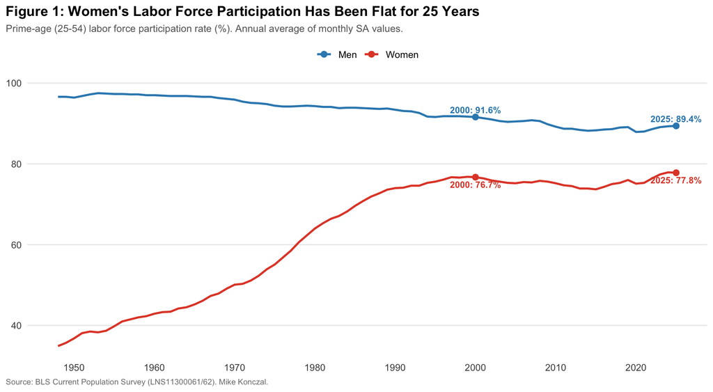

Figure 1

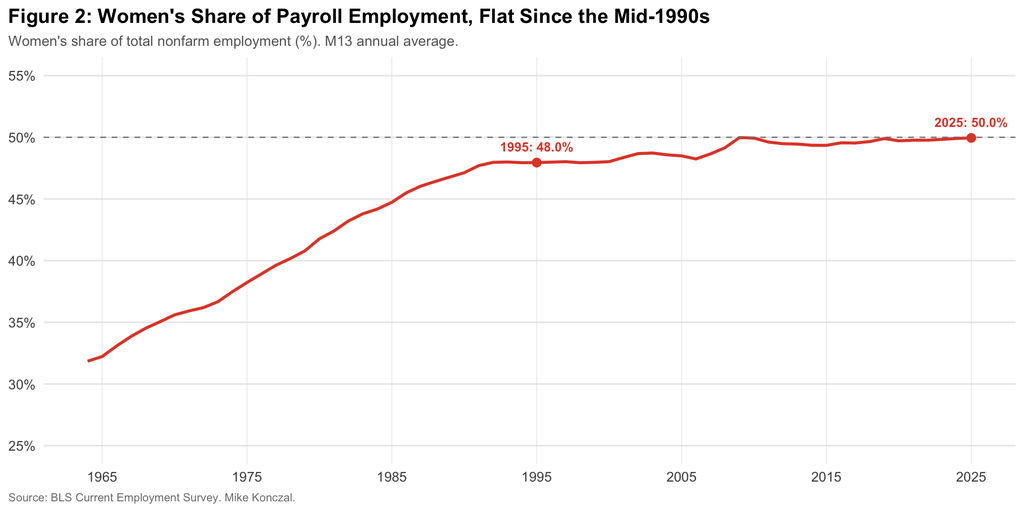

Figure 2

Table 1: Labor Force Participation Rate (%), Ages 25-29. Source: IPUMS CPS. Mike Konczal.

| Sex | Education | 1992 | 2019 | 2024 |
| --- | --- | --- | --- | --- |
| Men | College (BA+) | 94.1 | 90.5 | 91.3 |
| Women | College (BA+) | 87.2 | 86.7 | 86.7 |
| Men | Non-College | 92.8 | 86.2 | 85.6 |
| Women | Non-College | 70.2 | 72.0 | 71.4 |

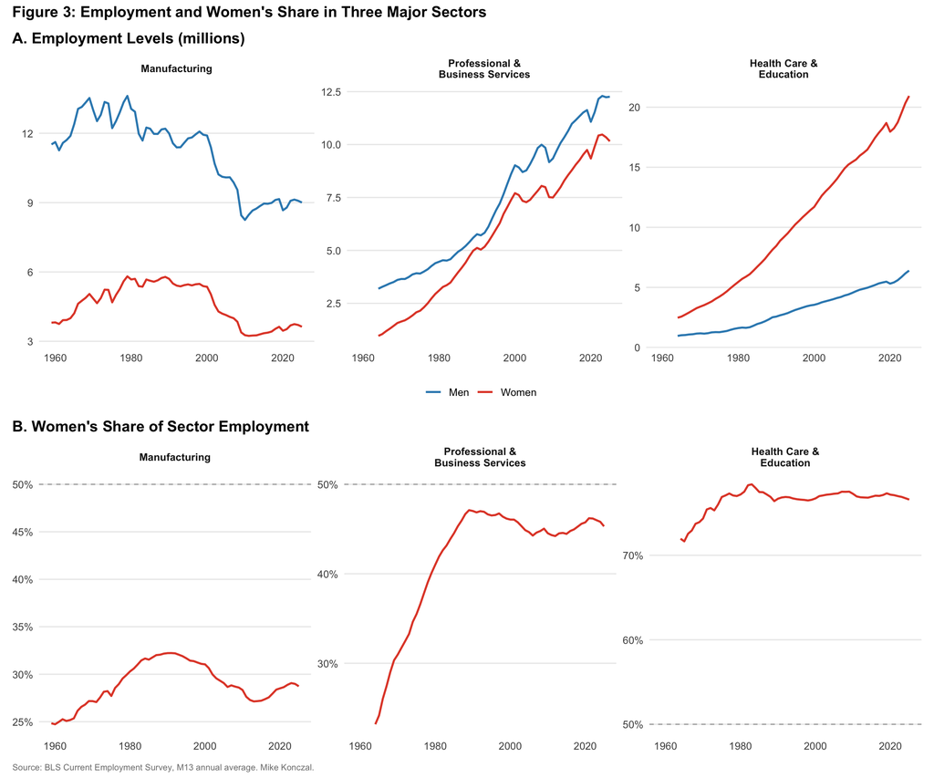

Figure 3

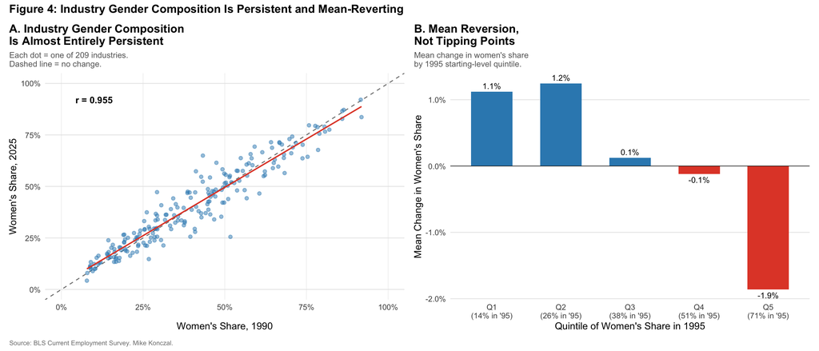

Figure 4

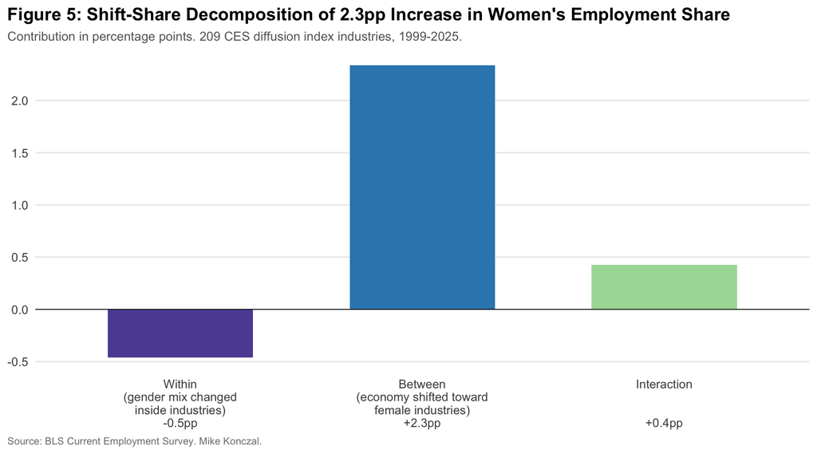

Figure 5

The shift-share decomposition separates the aggregate change in women’s employment share into three components. Let $s_{it}$ be women’s share of employment in industry $i$ at time $t$, and $w_{it}$ be industry $i$’s share of total employment. The aggregate women’s share is $\bar{s}_t = \sum_i w_{it} \, s_{it}$. We decompose its change from period 0 to period 1 as:

$$\Delta \bar{s} = \underbrace{\sum_i w_{i0} \, \Delta s_i}_{\textbf{Within}} + \underbrace{\sum_i \Delta w_i \cdot s_{i0}}_{\textbf{Between}} + \underbrace{\sum_i \Delta w_i \cdot \Delta s_i}_{\textbf{Interaction}}$$

where $\Delta s_i = s_{i1} - s_{i0}$ and $\Delta w_i = w_{i1} - w_{i0}$.

- **Within**: Holding industry employment shares fixed at their 1999 values, how much did the gender composition change *inside* industries? A positive value means industries became more female on average.
- **Between**: Holding each industry’s gender mix fixed at its 1999 level, how much did the *reallocation of employment across industries* change the aggregate? A positive value means the economy shifted toward industries that were already more female.
- **Interaction**: A cross-term capturing industries that both grew *and* became more female (or shrank and became more male). Usually small.

This decomposition is **exact**: the three terms sum precisely to the total change, with no approximation or residual.

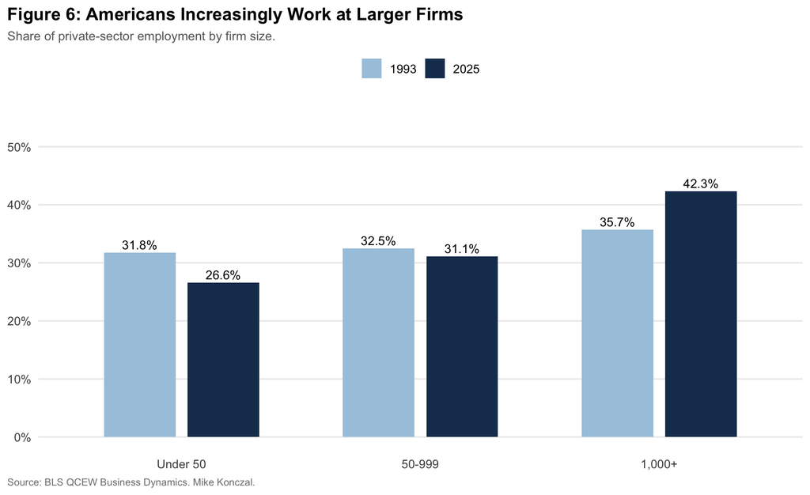

Figure 6

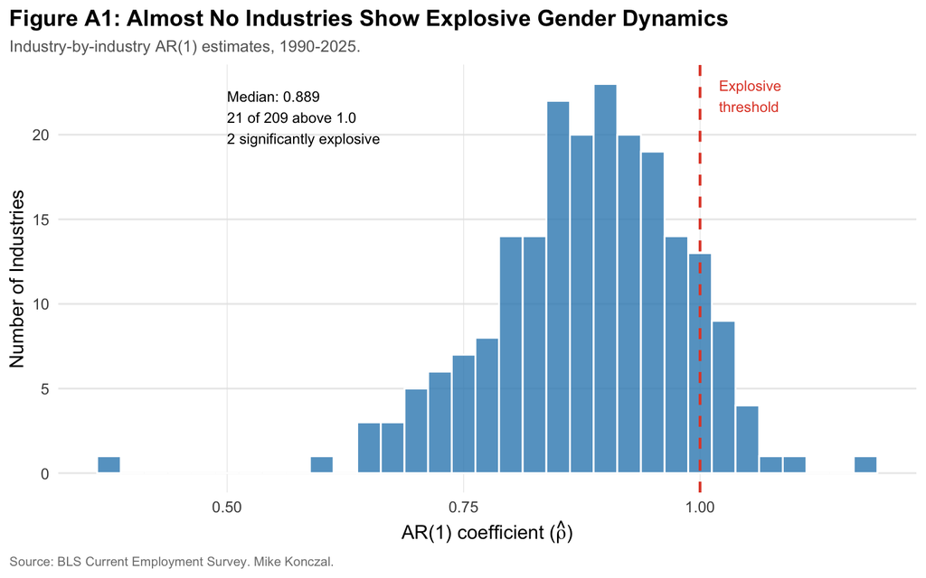

Figure 7